# Data Management Plan

Co-Investigator - Thomas Morell, Caltech

Key Personnel - Donna Wrublewski and Robert Doiel, Caltech

Monday, July 16, 2018

```r
# Add the dataset of DOAJ Seal journals

doaj_seal <- read_csv('DOAJ_Seal.csv')
```

# 1 Administrative Data

## 1.1 ID

*Not Applicable*

## 1.2 Funder

This research is being submitted for funding to the [J. Bohannon Foundation](http://www.johnbohannon.org/).

## 1.3 Grant Reference Number

*Not Applicable* (Proposal in preparation)

## 1.4 Project Name

*Do Reputable Open Access Journals Require Open Data Sharing?*

## 1.5 Project Description

This study analyzes the submission requirements of the most reputable open access journals to determine the prevalence and characteristics of data sharing policies. This question is an important one for 21<sup>st</sup> century authors and readers because open data sharing is seen as a key component of open and more trusted scientific record.

According to the Research Data Alliance (RDA) [Data Policy Standardisation and Implementation group](https://www.rd-alliance.org/groups/data-policy-standardisation-and-implementation):

> “the prevalence of research data policies from institutions and research funders is increasing, so publishers and editors are paying more attention to standardisation and the wider adoption of data sharing policies.”

This study investigates whether the **most reputable Open Access journals** have data sharing polices and the characteristics of those policies. These policies require authors, in some fashion, to openly disseminate the data and software underlying their published articles.

Our investigation builds on the recent work of Castro et al. (2017) who assessed the prevalence and characteristics of data sharing policies from randomly-selected, English-language, open access journals. Their findings reveal that only a small minority of these journals have data sharing policies. These findings – which are consistent with those of other studies [see for example, (“Reproducible and Reusable Research: Are Journal Data Sharing Policies Meeting the Mark?” n.d.)) – may be skewed because of the authors’ rules of inclusion and exclusion (in particular, the choice to include open access journals merely because of their use of the Open Journal Systems (OJS) hosting platform; the choice to exclude non_English language journals).

**DOAJ Seal** journals are considered the most reputable because they:

> “achieve a high level of openness, adhere to Best Practice and high publishing standards.The Seal is awarded to a journal that fulfills a set of criteria related to accessibility, openness, discoverability, reuse and author rights. It acts as a signal to readers and authors that the journal has generous use and reuse terms, author rights and adheres to the highest level of ‘openness’.”[^1]

Moreover, the DOAJ Seal journals do include over 200 non-English language journals that merit analysis in this study. Excluding these from the analysis represents cultural bias that undermines reliable research.

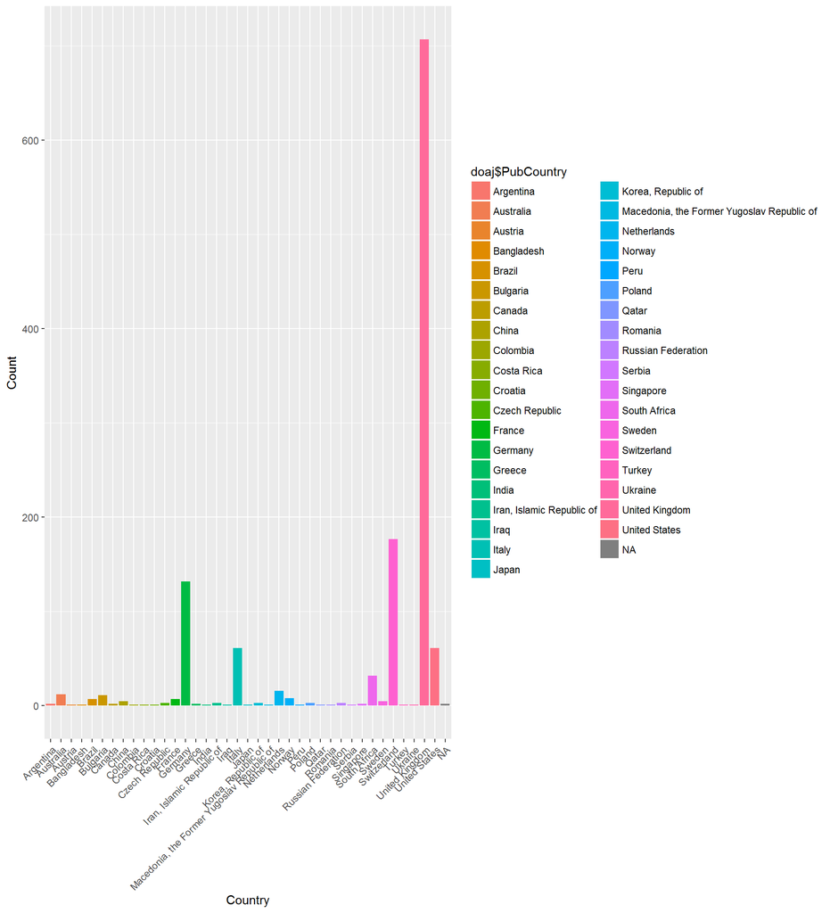

## 1.9 Date of First Version

Thursday, May 17, 2018

## 1.10 Date of Last Update

Monday, July 16, 2018

## 1.11 Related Policies

1. All original data, code, or reports produced as part of this project are owned by Trieste Polytechnic Elsevier Inc per its institutional intellectual property policy.
2. The J. Bohannan Foundation adheres to the open access and data sharing policies of the [Gates Foundation](https://www.gatesfoundation.org/How-We-Work/General-Information/Open-Access-Policy)

# 2 Data Collection

## 2.1 Existing Data Being Reused

This study relies on the *DOAJ Journal Metadata* available as a `csv` file download from the [DOAJ website](https://doaj.org/faq#metadata). The `csv` file is updated every 30 minutes.

This data will be read into the open source tool `OpenRefine` to filter it for those journals awarded the DOAJ Seal, and to remove unneeded columns containing the web addresses for journal policies around plagiarism, submission fees, and other urls not related to this study.

The filtered version of the data set will be exported as a new file named `doaj_seal.csv` for importing into analytical software.

A sample of the `doaj_seal.csv` data set is shown below. The complete data set is available in searchable and broweseable format as Annex 10.1 at the end of this document.

```r
knitr::kable(head(doaj_seal, 4), caption = 'A Table of the first 4 rows of the DOAJ Seal data.')
```

A Table of the first 4 rows of the DOAJ Seal data.

| JnlTitle | Publisher | PubCountry | Fee | WaiverPolicy | Identifiers | FirstYear | Language | ReviewProcess | Plagiarism | Sub2Pub | JnlLicense | AuthorCopyright | DOAJ_Seal |
| --- | --- | --- | --- | --- | --- | --- | --- | --- | --- | --- | --- | --- | --- |
| Archives Animal Breeding | Copernicus Publications | Germany | No | Yes | DOI | 1999 | English | Peer review | Yes | 13 | CC BY | TRUE | Yes |
| Bothalia: African Biodiversity & Conservation | AOSIS | South Africa | No | NA | DOI | 2014 | English | Double blind peer review | Yes | 12 | CC BY | TRUE | Yes |
| Geographica Helvetica | Copernicus Publications | Germany | No | Yes | DOI | 1946 | English, French, German, Italian | Double blind peer review | Yes | 53 | CC BY | TRUE | Yes |
| Hereditas | BioMed Central | United Kingdom | Yes | Yes | DOI | 2005 | English | Blind peer review | Yes | 6 | CC BY | TRUE | Yes |

## 2.2 Data being collected

The `doaj_seal.csv` data set currently includes 1281 reputable open access journals that we will investigate in this study. To accommote the additional journal metadata discovered during the journal evaluation process, `doaj_seal.csv` will be copied and enhanced with additional columns, resulting in the processed dataset, `doaj_seal_enhanced.csv`. The following columns will be added to `doaj_seal.csv`, in conformance with the Coding Framework of Castro et al. (2017).

Investigators will examine the websites of each journal listed in the `doaj_seal_enhanced.csv` file to determine whether the data sharing policy is included in the Instructions to Authors. The Coding Framework published by Castro et al. (2017) will be applied.

[figure not shown]

### 2.2.1 Metadata

The journal metadata contained in the project’s data sets comes directly from the *Directory of Open Access Journals*.

The final outputs from the project will be documented in metadata files according to the DataCite DOI registration agency – see the [DataCite Metadata Schema 4.1](https://schema.datacite.org/) for specific details. By following this standard metadata format, other researchers (and computers) will be able to find, access, and reuse the outputs from this project by searching the DataCite metadatabase.

# 3 Ethics and Legal Compliance

- No additional ethical or privacy issues arise in this study because both the *DOAJ data*, and the information about data policies for any published journal, are publicly posted online.
- The data provided about journals awarded the *Directory of Open Access Journals* Seal of Approval is distributed under a CC BY-SA license. This license requires that reusers of the data share their derivative data set under the same license. Therefore, the output of this research will be disseminated under the CC BY-SA license. This license adheres to the *Principles and Guidelines of the Research Data Alliance Legal Interoperability Group*, which recommends the use of Creative Commons Attribution licenses to allow the broadest sharing of data while guaranteeing attribution to the data provider.[^2]

# 4 Data collection and standards

All data retrieved for the DOAJ Seal of Approval are downloaded and stored in the open `common separated value` (`csv`) file format.

All data policies culled from the web sites of the DOAJ seal journals will be saved as `.txt` files. The data generated by applying Castro et al. (2017) Coding Framework will be stored in `csv` file format.

Analysis, visualization, and summarization of the study’s findings will be performed in the open source software `R` and `RStudio` using the `tidyverse` package (Wickham 2017). Reports produced from the study will be also be created in `RStudio` using the open source text format `Rmarkdown` and output to `HTML` documents, slides, and `MS Word` documents for submission to funders or publishers.

All files associated with the project will be maintained under the `Git` version control system and made openly available for download from the Principal Investigator’s `GitHub` repository.

# 5 Storage and Backup

During the active phase of the project data will be stored on and backed up to the Research Data Storage Facility (RDSF) at Elsevier Inc. This facility represents 2 million pounds of digital resilient storage, with ongoing capital investment. The RDSF is overseen by a steering group of senior research and support staff, which includes the PVC Research. Backup procedures are robust (overnight backup, copies held remotely on tape) and secured access is in place

# 6 Deposit and long-term preservation

After the project conclusion, all research outputs will be assigned Digital Object Identifiers by DataCite to serve as persistent identifiers and to always resolve to the landing page for the project files (metadata, data, code, and reports).

Additionally, the Research Data Storage Facility (RDSF) at Elsevier Inc will undertake to preserve each of the digital outputs mentioned above, for three years beyond the end of the project. Refreshment of storage media will be scheduled as required

# 7 Selection and Preservation

The final complete data set `doaj_seal_enhanced` and all published outputs produced based on this data set will be issued Digital Object Identifiers and stored on `GitHub` and `Zenodo`. All draft versions of project outputs will also be publicly available in Git Hub with unique hashes distinguishing each version that predates the final.

# 8 Data Sharing

The data and metadata will be made openly accessible under a CC-BY SA license in the CERN-maintained open access repository [`Zenodo`](https://zenodo.org/), an open dependable home for the long-tail of science, enabling researchers to share and preserve any research outputs in any size, any format and from any science.[^3]

# 9 Responsibilities and Resources

The Principal Investigator is responsible for implementing the Data management Plan and ensuring it is reviewed and revised as necessary. (S)he will be responsible for all data collection and recording; for data analysis and visualization; and for maintain all files under version control using `git` and `GitHub`.

The Data Management Specialist assigned to the project as an in-kind contribution from the Elsevier Inc Library will be responsible for creating the DataCite metadata documentation for all outputs and ensuring timely DOI registration of each final output. (S)he will also deposit all final outputs to the Zenodo repository and update metadata associated with the DOI as necessary.

# 10 Annexes

## 10.1 Complete dataset `doaj_seal.csv`

```r
doaj_seal %>%
  datatable(rownames = FALSE,
            colnames = c("Title", "Publisher", "Country", "Fees", "Waivers", "Identifiers", "Start Year", "Language(s)", "Review  Process", "Plagiarism check", "Time to Press", "License", "Author owns Copyright", "DOAJ Seal"),
            class = "cell-border stripe",
            caption = "Journals with DOAJ Seal",
            filter = list(position = "bottom"),
            extensions = 'Buttons', options = list(dom = 'Bfrtip',
                                                   buttons = c('colvis', 'csv', 'pdf'))
  )
```

| Title | Publisher | Country | Fees | Waivers | Identifiers | Start Year | Language(s) | Review Process | Plagiarism check | Time to Press | License | Author owns Copyright | DOAJ Seal |
| --- | --- | --- | --- | --- | --- | --- | --- | --- | --- | --- | --- | --- | --- |
| Archives Animal Breeding | Copernicus Publications | Germany | No | Yes | DOI | 1999 | English | Peer review | Yes | 13 | CC BY | True | Yes |
| Bothalia: African Biodiversity &amp; Conservation | AOSIS | South Africa | No |  | DOI | 2014 | English | Double blind peer review | Yes | 12 | CC BY | True | Yes |
| Geographica Helvetica | Copernicus Publications | Germany | No | Yes | DOI | 1946 | English, French, German, Italian | Double blind peer review | Yes | 53 | CC BY | True | Yes |
| Hereditas | BioMed Central | United Kingdom | Yes | Yes | DOI | 2005 | English | Blind peer review | Yes | 6 | CC BY | True | Yes |
| Landtechnik | Kuratorium für Technik und Bauwesen in der Landwirtschaft e. V. | Germany | No |  | DOI | 2015 | English, German | Blind peer review |  | 16 | CC BY | True | Yes |
| Onderstepoort Journal of Veterinary Research | AOSIS | South Africa | No |  | DOI | 2003 | English | Double blind peer review | Yes | 16 | CC BY | True | Yes |
| Phytopathologia Mediterranea | Firenze University Press | Italy | Yes |  | DOI | 2014 | English | Peer review |  | 8 | CC BY | True | Yes |
| Psyche: A Journal of Entomology | Hindawi Limited | United Kingdom | Yes | Yes | DOI | 1874 | English | Blind peer review | Yes | 15 | CC BY | True | Yes |
| Psychologica Belgica | Ubiquity Press | United Kingdom | Yes |  | DOI | 2004 | English | Double blind peer review | Yes | 4 | CC BY | True | Yes |
| South African Journal of Science | Academy of Science of South Africa | South Africa | No |  | DOI | 2009 | English | Double blind peer review | Yes | 52 | CC BY | True | Yes |

[output cut: 1271 more lines]

## 10.2 Principal Investigator’s BioSketch

*This will be auto-populated from your ORCID profile using the Chamberlain (2018) `rorcid` package.*

Gail Clement is a Library Administrator and science research librarian at the Caltech Library. She oversees a team of subject librarians, repository, metadata and licensing specialists who develop knowledge management resources, publishing services, and authorship programs for the Caltech community. In this role she also represents Caltech Library on the Organizational Advisory Assembly for the Research Data Alliance, the Committee on Publication Ethics, the Overleaf Steering Committee, and the ORCID Curriculum working group. She is a certified Data Carpentry Instructor, specializing in research data cleaning and enhancement; data sharing; and citation and publication of all research outputs.

As Coordinator of Author Carpentry - a researcher training program in 21st century authorship and publishing - Gail collaborates with developers and researchers to create practical, hands-on, and useful lessons in responsible, reproducible, and reuseable open publication. Author Carpentry builds on a pilot lesson from Software Carpentry on Scientific Authorship. Author Carpentry workshops are offered at Caltech and through professional groups such as the CODATA-RDA Summer School in Research Data Science, the Force11 Scholarly Communication Institute, and the Association for Artificial Intelligence 2017 Tutorial Forum.

Gail’s professional leadership and service includes mentoring researchers from developing nations via Author Aid; Co-Chair of the CODATA-Research Data Alliance Group on Legal Interoperability of Research Data; and service on the Editorial Board for the Journal of Librarianship and Scholarly Communication (JLSC) where she co-edited the 2015 special issue on data sharing, data publication, and data citation. She serves on the License Review Committee and the Scholarly Communication Taskforce of the Statewide California Electronic Library Consortium; on the Library Advisory Committee for Ubiquity Press; and as a Collection Editor for “Research Paper of the Future” on ScienceOpen.

# References

Castro, Eleni, Merc‘ Crosas, Alex Garnett, Kasey Sheridan, and Micah Altman. 2017. “Evaluating and Promoting Open Data Practices in Open Access Journals.” *Journal of Scholarly Publishing* 49 (1). University of Toronto Press Inc. (UTPress): 66–88. doi:10.3138/jsp.49.1.66.

Chamberlain, Scott. 2018. *Rorcid: Interface to the ’Orcid.org’ ’Api’*. https://CRAN.R-project.org/package=rorcid.

“Reproducible and Reusable Research: Are Journal Data Sharing Policies Meeting the Mark?” n.d. 5. doi:10.7717/peerj.3208.

Wickham, Hadley. 2017. *Tidyverse: Easily Install and Load the ’Tidyverse’*. https://CRAN.R-project.org/package=tidyverse.

Xie, Yihui, J. J. Allaire, and Garrett Grolemund. 2018. *R Markdown - the Definitive Guide*. Chapman & Hall/CRC. http://dx.doi.org/10.1038/nmat3283.

[^1]: DOAJ selection for Seal Approval is explained in the FAQ at https://doaj.org/faq#seal
[^2]: https://www.rd-alliance.org/rda-codata-legal-interoperability-research-data-principles-and-implementation-guidelines-now
[^3]: Zenodo policies are available online at http://about.zenodo.org/policies/